# WHI Abuse and Sexual Function

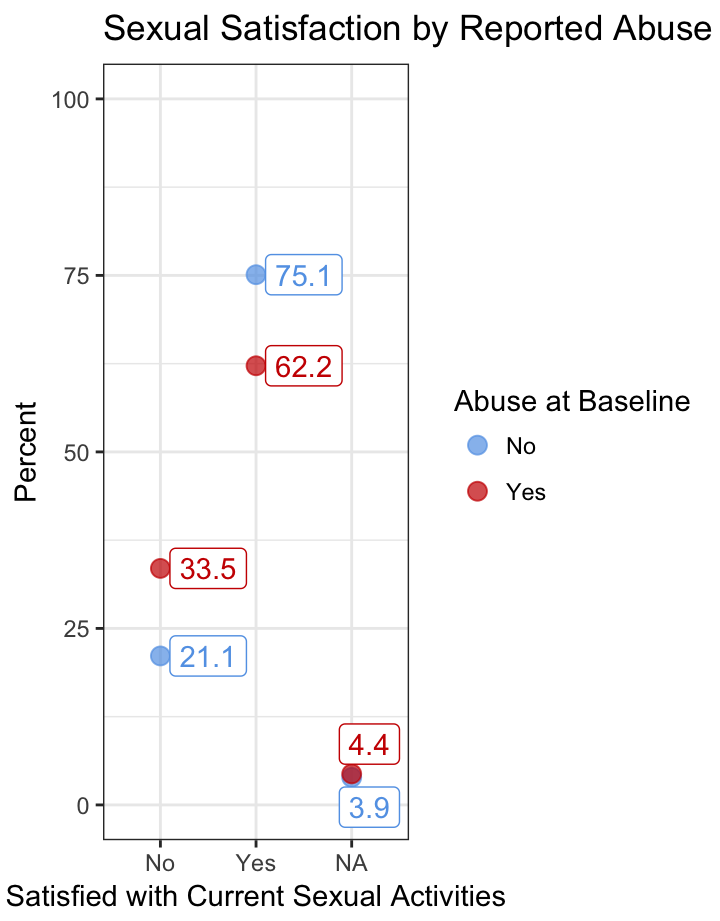

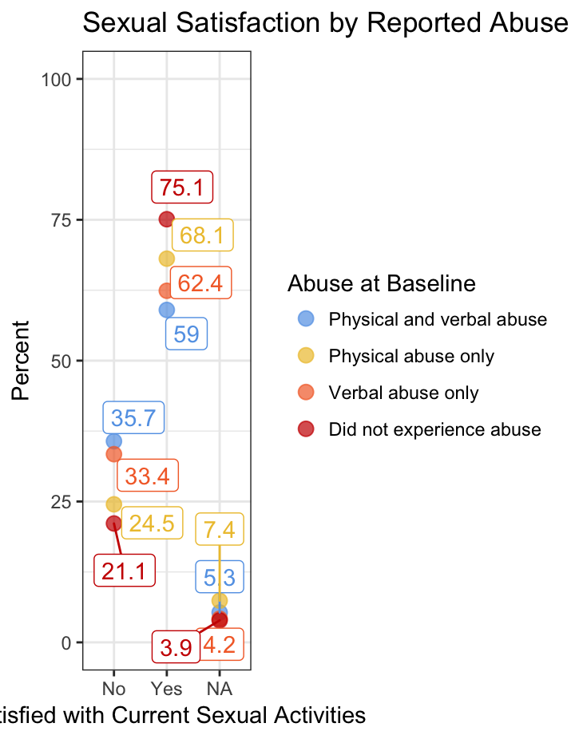

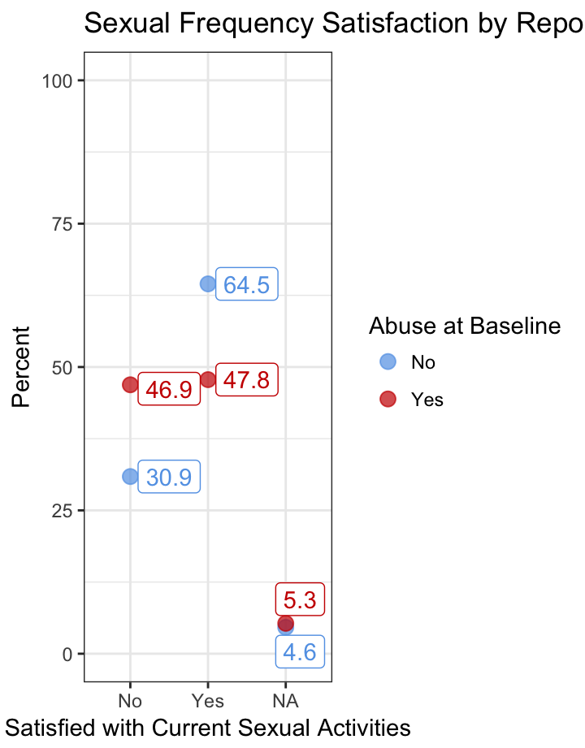

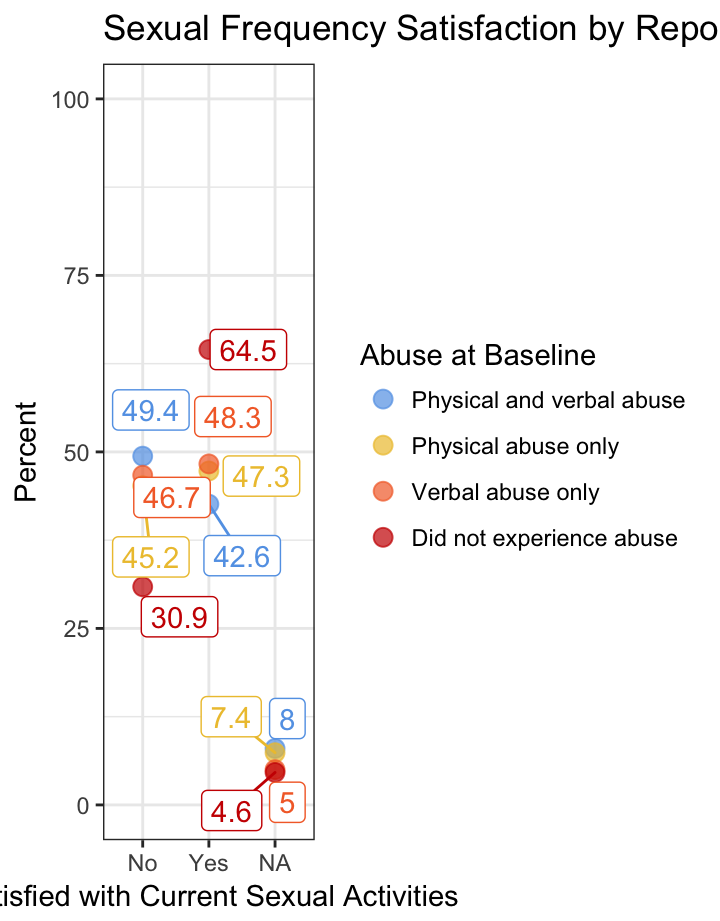

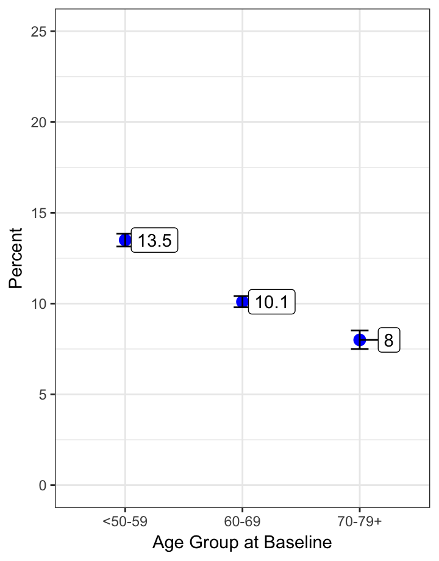

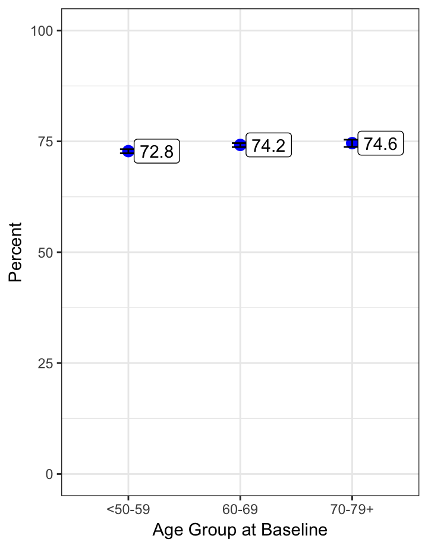

[figure not shown]

All analyses include information from women who participated in the [WHI](https://www.whi.org/SitePages/WHI%20Home.aspx), gave a “yes” or “no” response to the two questions related to abuse, and reported being sexually active in the previous year.

Please use the navigation bar (blue bar at the top of the screen) to view:

1. **Table 1.** Sociodemographic and health history characteristics of women participating in the WHI by abuse experience at baseline
2. **Figure 1.** Percent of women who reported abuse at baseline by age group
3. **Figure 2.** Percent of women who reported sexual satisfaction at baseline by age group
4. **Figure 3.** Percent of women who reported sexual frequency satisfaction at baseline by age group
5. **Table 2.** Unadjusted and adjusted odds of global sexual dissatisfaction and sexual frequency dissatisfaction at baseline
6. **Table 3.** Number and percent of women who report sexual satisfaction and sexual frequency satisfaction at baseline by age group and abuse status

# Overview

### Reported No Abuse at Baseline

73,759

### Reported Any Abuse at Baseline

9,386

### Reported Verbal Abuse Only at Baseline

8,374

### Reported Physical Abuse Only at Baseline

188

### Reported Physical and Verbal Abuse at Baseline

824

### Sexual Satisfaction by Reported Abuse at Baseline

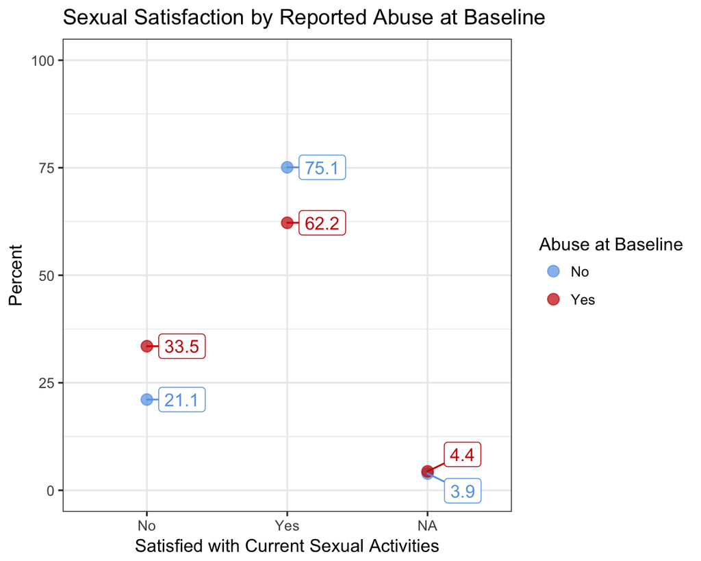

### Sexual Satisfaction by Reported Abuse at Baseline

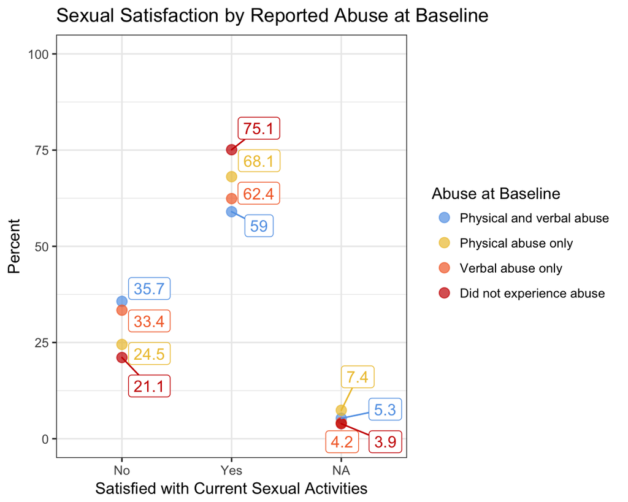

### Sexual Frequency Satisfaction by Reported Abuse at Baseline

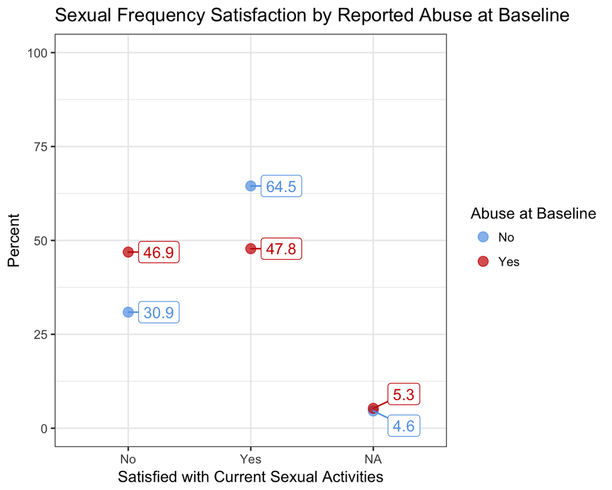

### Sexual Frequency Satisfaction by Reported Abuse at Baseline

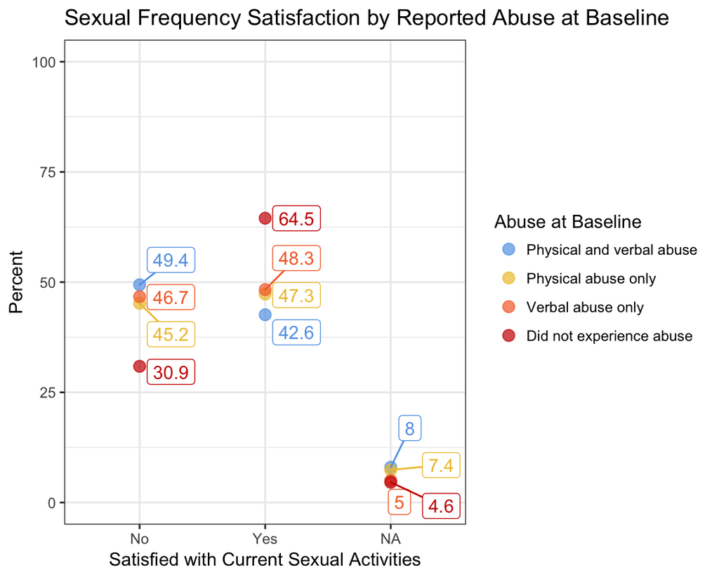

# Table 1

### Download in Word Format

[Click here to download Table 1 in Word Format](https://github.com/brad-cannell/whi_sexual_function/blob/master/R%20notebooks/table_1_word.docx)

### Table 1 Sociodemographic and health history characteristics of women participating in the WHI by abuse experience at baseline (N = 83,145)<sup>1</sup>

| Characteristic | Class | No Abuse | Any Abuse | Verbal Only | Physical Only | Verbal and Physical |
| --- | --- | --- | --- | --- | --- | --- |
|  |  | N = 73,759 | N = 9,386 | N = 8,374 | N = 188 | N = 824 |
| Age, mean (sd) |  | 61.41 (6.78) | 59.93 (6.55) | 60.08 (6.54) | 59.65 (6.49) | 58.46 (6.48) |
| Age group, n (%) | <50-59 | 30,955 (42.0 %) | 4,830 (51.5 %) | 4,234 (50.6 %) | 97 (51.6 %) | 499 (60.6 %) |
|  | 60-69 | 32,708 (44.3 %) | 3,677 (39.2 %) | 3,335 (39.8 %) | 76 (40.4 %) | 266 (32.3 %) |
|  | 70-79+ | 10,096 (13.7 %) | 879 ( 9.4 %) | 805 ( 9.6 %) | 15 ( 8.0 %) | 59 ( 7.2 %) |
| Race and Ethnicity, n (%) | White | 62,361 (84.7 %) | 7,695 (82.1 %) | 7,034 (84.2 %) | 119 (63.3 %) | 542 (65.9 %) |
|  | AA | 5,740 ( 7.8 %) | 761 ( 8.1 %) | 584 ( 7.0 %) | 44 (23.4 %) | 133 (16.2 %) |
|  | Hispanic | 2,687 ( 3.7 %) | 514 ( 5.5 %) | 410 ( 4.9 %) | 13 ( 6.9 %) | 91 (11.1 %) |
|  | Other | 2,810 ( 3.8 %) | 398 ( 4.2 %) | 329 ( 3.9 %) | 12 ( 6.4 %) | 57 ( 6.9 %) |
| Education, n (%) | <HS | 2,885 ( 3.9 %) | 433 ( 4.6 %) | 320 ( 3.8 %) | 24 (12.9 %) | 89 (10.9 %) |
|  | HS Grad | 12,361 (16.9 %) | 1,376 (14.8 %) | 1,223 (14.7 %) | 31 (16.7 %) | 122 (15.0 %) |
|  | Some College or Tech School | 27,297 (37.3 %) | 3,805 (40.9 %) | 3,359 (40.4 %) | 76 (40.9 %) | 370 (45.3 %) |
|  | College Grad | 30,717 (41.9 %) | 3,700 (39.7 %) | 3,410 (41.0 %) | 55 (29.6 %) | 235 (28.8 %) |
| Income, n (%) | 20,000 or less | 5,548 ( 8.0 %) | 1,078 (12.3 %) | 839 (10.7 %) | 41 (23.7 %) | 198 (25.7 %) |
|  | 20-34,999 | 13,181 (19.1 %) | 1,847 (21.1 %) | 1,628 (20.8 %) | 33 (19.1 %) | 186 (24.2 %) |
|  | 35-49,999 | 14,483 (21.0 %) | 1,854 (21.1 %) | 1,688 (21.6 %) | 35 (20.2 %) | 131 (17.0 %) |
|  | 50-74,999 | 16,871 (24.4 %) | 1,965 (22.4 %) | 1,797 (23.0 %) | 34 (19.7 %) | 134 (17.4 %) |
|  | 75,000+ | 18,934 (27.4 %) | 2,025 (23.1 %) | 1,875 (24.0 %) | 30 (17.3 %) | 120 (15.6 %) |
| Married, n (%) | Not married or intimate relationship | 9,818 (13.8 %) | 1,519 (16.8 %) | 1,233 (15.3 %) | 48 (26.7 %) | 238 (30.4 %) |
|  | Married or intimate relationship | 61,553 (86.2 %) | 7,527 (83.2 %) | 6,850 (84.7 %) | 132 (73.3 %) | 545 (69.6 %) |
| Who you have had sex with, n (%) | Have never had sex | 0 ( 0.0 %) | 0 ( 0.0 %) | 0 ( 0.0 %) | 0 ( 0.0 %) | 0 ( 0.0 %) |
|  | Sex with a woman or with women | 176 ( 0.2 %) | 24 ( 0.3 %) | 19 ( 0.2 %) | 0 ( 0.0 %) | 5 ( 0.6 %) |
|  | Sex with a man or with men | 71,649 (98.7 %) | 9,077 (98.4 %) | 8,131 (98.5 %) | 179 (100.0 %) | 767 (96.5 %) |
|  | Sex with both men and women | 736 ( 1.0 %) | 125 ( 1.4 %) | 102 ( 1.2 %) | 0 ( 0.0 %) | 23 ( 2.9 %) |
| Clinical trial or observational study, n (%) | CT | 30,777 (41.7 %) | 4,052 (43.2 %) | 3,602 (43.0 %) | 78 (41.5 %) | 372 (45.1 %) |
|  | OS | 42,982 (58.3 %) | 5,334 (56.8 %) | 4,772 (57.0 %) | 110 (58.5 %) | 452 (54.9 %) |
| Parity, n (%) | Never had term pregnancy | 5,963 ( 8.1 %) | 674 ( 7.2 %) | 599 ( 7.2 %) | 15 ( 8.1 %) | 60 ( 7.3 %) |
|  | 1 | 5,840 ( 8.0 %) | 764 ( 8.2 %) | 671 ( 8.1 %) | 14 ( 7.5 %) | 79 ( 9.7 %) |
|  | 2 | 19,846 (27.1 %) | 2,495 (26.7 %) | 2,253 (27.0 %) | 43 (23.1 %) | 199 (24.3 %) |
|  | 3 | 19,407 (26.5 %) | 2,401 (25.7 %) | 2,151 (25.8 %) | 55 (29.6 %) | 195 (23.8 %) |
|  | 4 | 11,839 (16.1 %) | 1,549 (16.6 %) | 1,383 (16.6 %) | 30 (16.1 %) | 136 (16.6 %) |
|  | 5+ | 10,460 (14.3 %) | 1,452 (15.6 %) | 1,274 (15.3 %) | 29 (15.6 %) | 149 (18.2 %) |
| Physical activity (MET-hours/week), mean (sd) |  | 13.65 (14.18) | 12.63 (14.24) | 12.70 (14.15) | 12.93 (13.17) | 11.82 (15.40) |
| Alcohol servings per week, mean (sd) |  | 2.63 (4.98) | 2.43 (5.03) | 2.43 (4.87) | 2.47 (5.44) | 2.34 (6.40) |
| Dietary caffeine (mg), mean (sd) |  | 150.70 (125.70) | 154.55 (145.79) | 159.19 (146.46) | 115.13 (89.42) | 129.41 (147.02) |
| Smoking status, n (%) | Never smoked | 35,105 (53.3 %) | 4,268 (51.1 %) | 3,841 (51.4 %) | 76 (46.3 %) | 351 (49.0 %) |
|  | Past smoker | 26,979 (41.0 %) | 3,405 (40.8 %) | 3,059 (40.9 %) | 73 (44.5 %) | 273 (38.1 %) |
|  | Current smoker | 3,770 ( 5.7 %) | 681 ( 8.2 %) | 574 ( 7.7 %) | 15 ( 9.1 %) | 92 (12.8 %) |
| Female hormones ever, n (%) | No | 298 ( 0.6 %) | 44 ( 0.7 %) | 38 ( 0.6 %) | 1 ( 0.8 %) | 5 ( 0.9 %) |
|  | Yes | 51,857 (99.4 %) | 6,711 (99.3 %) | 6,041 (99.4 %) | 121 (99.2 %) | 549 (99.1 %) |
| Female hormones now, n (%) | No | 173 (25.1 %) | 27 (33.3 %) | 25 (34.7 %) | 0 ( 0.0 %) | 2 (25.0 %) |
|  | Yes | 517 (74.9 %) | 54 (66.7 %) | 47 (65.3 %) | 1 (100.0 %) | 6 (75.0 %) |
| Taking SSRI, n (%) | No | 22,775 (96.1 %) | 2,666 (92.8 %) | 2,396 (92.7 %) | 56 (93.3 %) | 214 (93.0 %) |
|  | Yes | 921 ( 3.9 %) | 208 ( 7.2 %) | 188 ( 7.3 %) | 4 ( 6.7 %) | 16 ( 7.0 %) |
| Quality of life, mean (sd) |  | 8.57 (1.28) | 7.61 (1.65) | 7.65 (1.61) | 7.98 (1.54) | 7.16 (1.98) |
| Shortened CES-D/DIS, mean (sd) |  | 0.03 (0.10) | 0.09 (0.20) | 0.09 (0.19) | 0.06 (0.15) | 0.18 (0.26) |
| Body Mass Index, mean (sd) |  | 26.98 (5.44) | 27.78 (5.95) | 27.65 (5.88) | 29.22 (6.92) | 28.74 (6.31) |
| Good or better health, n (%) | No | 26,404 (35.9 %) | 4,343 (46.4 %) | 3,795 (45.4 %) | 94 (50.0 %) | 454 (55.3 %) |
|  | Yes | 47,163 (64.1 %) | 5,024 (53.6 %) | 4,563 (54.6 %) | 94 (50.0 %) | 367 (44.7 %) |
| Hysterectomy ever, n (%) | No | 711 ( 2.3 %) | 79 ( 1.9 %) | 73 ( 2.0 %) | 1 ( 1.2 %) | 5 ( 1.2 %) |
|  | Yes | 30,740 (97.7 %) | 4,158 (98.1 %) | 3,666 (98.0 %) | 80 (98.8 %) | 412 (98.8 %) |
| Night sweats, n (%) | No | 53,778 (73.2 %) | 6,011 (64.4 %) | 5,449 (65.4 %) | 98 (53.3 %) | 464 (56.7 %) |
|  | Yes | 19,640 (26.8 %) | 3,329 (35.6 %) | 2,889 (34.6 %) | 86 (46.7 %) | 354 (43.3 %) |
| Hot flashes, n (%) | No | 54,249 (73.7 %) | 6,210 (66.4 %) | 5,616 (67.3 %) | 109 (58.0 %) | 485 (59.1 %) |
|  | Yes | 19,313 (26.3 %) | 3,148 (33.6 %) | 2,733 (32.7 %) | 79 (42.0 %) | 336 (40.9 %) |
| Vaginal or genital dryness, n (%) | No | 48,788 (66.4 %) | 5,665 (60.6 %) | 5,085 (61.0 %) | 103 (55.4 %) | 477 (58.3 %) |
|  | Yes | 24,710 (33.6 %) | 3,677 (39.4 %) | 3,253 (39.0 %) | 83 (44.6 %) | 341 (41.7 %) |
| Ever leaked urine, n (%) | No | 19,928 (27.0 %) | 1,940 (20.7 %) | 1,692 (20.2 %) | 46 (24.5 %) | 202 (24.6 %) |
|  | Yes | 53,764 (73.0 %) | 7,436 (79.3 %) | 6,674 (79.8 %) | 142 (75.5 %) | 620 (75.4 %) |
| Chronic Disease, n (%) | None | 397 (38.1 %) | 40 (31.5 %) | 38 (33.3 %) | 0 ( 0.0 %) | 2 (22.2 %) |
|  | 2 conditions | 67 ( 6.4 %) | 8 ( 6.3 %) | 6 ( 5.3 %) | 1 (25.0 %) | 1 (11.1 %) |
|  | 3 conditions | 75 ( 7.2 %) | 8 ( 6.3 %) | 7 ( 6.1 %) | 0 ( 0.0 %) | 1 (11.1 %) |
|  | 4 conditions | 31 ( 3.0 %) | 9 ( 7.1 %) | 9 ( 7.9 %) | 0 ( 0.0 %) | 0 ( 0.0 %) |
|  | 5+ conditions | 6 ( 0.6 %) | 2 ( 1.6 %) | 2 ( 1.8 %) | 0 ( 0.0 %) | 0 ( 0.0 %) |
|  | Arthritis Only | 6 ( 0.6 %) | 2 ( 1.6 %) | 2 ( 1.8 %) | 0 ( 0.0 %) | 0 ( 0.0 %) |
|  | Breast Cancer Only | 0 ( 0.0 %) | 0 ( 0.0 %) | 0 ( 0.0 %) | 0 ( 0.0 %) | 0 ( 0.0 %) |
|  | Cervical Cancer Only | 0 ( 0.0 %) | 0 ( 0.0 %) | 0 ( 0.0 %) | 0 ( 0.0 %) | 0 ( 0.0 %) |
|  | Endometrial Cancer Only | 0 ( 0.0 %) | 0 ( 0.0 %) | 0 ( 0.0 %) | 0 ( 0.0 %) | 0 ( 0.0 %) |
|  | Ovarian Cancer Only | 0 ( 0.0 %) | 0 ( 0.0 %) | 0 ( 0.0 %) | 0 ( 0.0 %) | 0 ( 0.0 %) |
|  | Cardiovascular Disease Only | 2 ( 0.2 %) | 0 ( 0.0 %) | 0 ( 0.0 %) | 0 ( 0.0 %) | 0 ( 0.0 %) |
|  | Diabetes Only | 455 (43.7 %) | 58 (45.7 %) | 50 (43.9 %) | 3 (75.0 %) | 5 (55.6 %) |
|  | Hypertension Only | 1 ( 0.1 %) | 0 ( 0.0 %) | 0 ( 0.0 %) | 0 ( 0.0 %) | 0 ( 0.0 %) |
|  | Osteoporosis Only | 1 ( 0.1 %) | 0 ( 0.0 %) | 0 ( 0.0 %) | 0 ( 0.0 %) | 0 ( 0.0 %) |
|  | Peripheral Artery Disease Only | 1 ( 0.1 %) | 0 ( 0.0 %) | 0 ( 0.0 %) | 0 ( 0.0 %) | 0 ( 0.0 %) |

**Footnotes:**  
1. Baseline data for women who had any sexual activity with a partner in the previous year and had a known abuse status. Individual group n’s are not mutually exclusive.  
2. All percentages above are column percentages. For example, 42% of women who reported no abuse at baseline were in the <50 to 59 age group at baseline.

# Figure 1

### Percent, and 95% confidence interval, of Women Who Reported Abuse at Baseline by Age Group

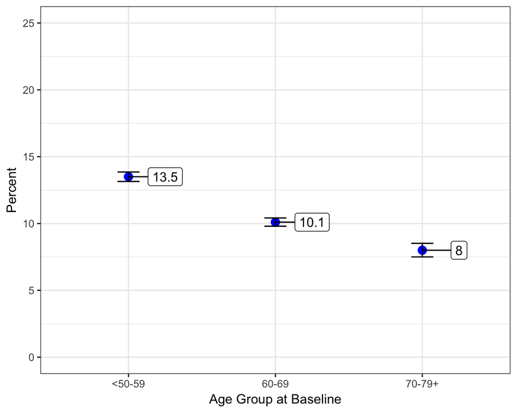

# Figure 2

### Percent, and 95% confidence interval, of Women Who Reported Sexual Satisfaction at Baseline by Age Group

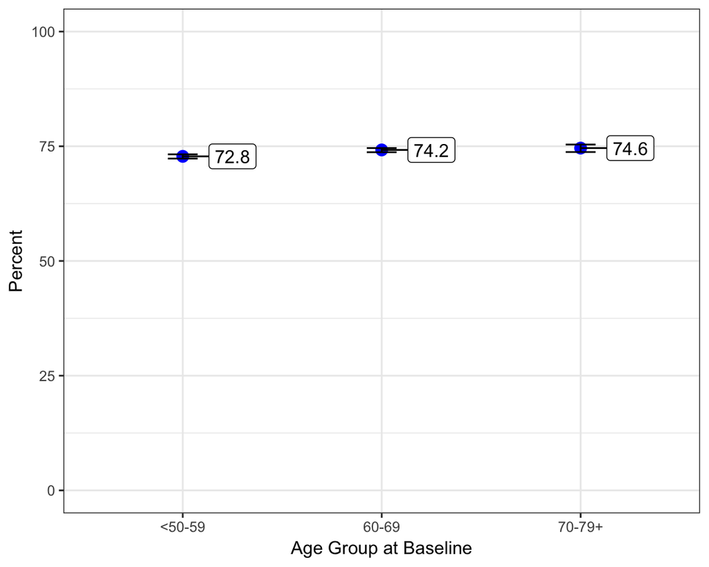

# Figure 3

### Percent, and 95% confidence interval, of Women Who Reported Sexual Frequency Satisfaction at Baseline by Age Group

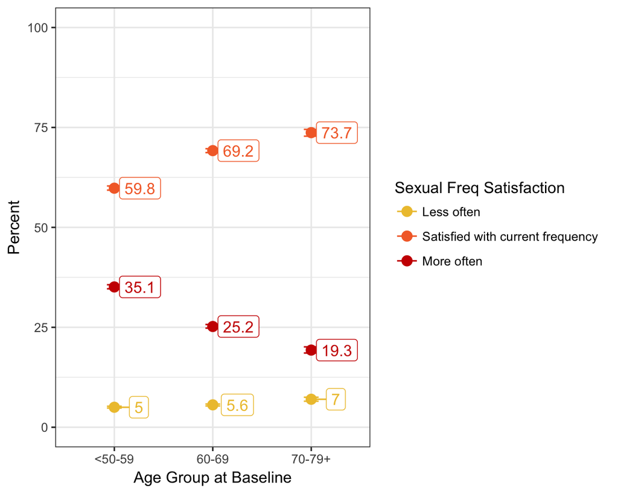

# Table 2

### Download in Word Format

[Click here to download Table 2 in Word Format](https://github.com/brad-cannell/whi_sexual_function/blob/master/R%20notebooks/table_2_word.docx)

| Recent Abuse | Unsatisfied with Sexual Activity Unadjusted | Unsatisfied with Sexual Activity Adjusted | Unsatisfied with Sexual Activity Frequency Unadjusted | Unsatisfied with Sexual Activity Frequency Adjusted |
| --- | --- | --- | --- | --- |
|  | OR (95% CI) | OR (95% CI) | OR (95% CI) | OR (95% CI) |
| No | Reference | Reference | Reference | Reference |
| Yes | 1.92 (1.83 - 2.01) | 1.48 (1.37 - 1.59) | 2.05 (1.96 - 2.15) | 1.56 (1.41 - 1.72) |

**Footnotes:**  
1. Adjusted for age, race/ethnicity, education, income, marital status, sexual orientation, study component, parity, alcohol consumption, caffeine consumption, smoking status, hormone use, use of SSRIs, quality of life, depression, BMI, self-rated health, hysterectomy, night sweats, hot flashes, vaginal dryness, urinary incontinence, chronic disease.  
2. How satisfied are you with your current sexual activities, either with a partner or alone?  
3. Are you satisfied with the frequency of your sexual activity, or would you like to have sex more or less often?  
4. Baseline data for women who had any sexual activity with a partner in the previous year, had a known abuse status, and responded to the sexual satisfaction questions.

# Table 3

### Download in Word Format

[Click here to download Table 3 in Word Format](https://github.com/brad-cannell/whi_sexual_function/blob/master/R%20notebooks/table_3_word.docx)

### **Table 3.** Number and percent of women who report sexual satisfaction<sup>1</sup> and sexual frequency satisfaction<sup>2</sup> at baseline by age group and abuse status, results from the Women’s Health Initiative (WHI) (N = 78,416)<sup>3</sup>.

| Age Group | Abuse Status | Satisfied with Sexual Activity | Unsatisfied with Sexual Activity | Satisfied with Sexual Frequency | Unsatisfied with Sexual Frequency | Desire Greater Sexual Frequency |
| --- | --- | --- | --- | --- | --- | --- |
|  |  | N = 60,321 | N = 18,095 | N = 51,682 | N = 26,734 | N = 22,568 |
|  |  | N (%) | N (%) | N (%) | N (%) | N (%) |
| All | No | 54,583 (78.4) | 15,075 (21.6) | 47,241 (67.8) | 22,417 (32.2) | 19,093 (27.4) |
|  | Yes | 5,738 (65.5) | 3,020 (34.5) | 4,441 (50.7) | 4,317 (49.3) | 3,475 (39.7) |
|  | Verbal abuse only | 5,143 (65.6) | 2,699 (34.4) | 4,006 (51.1) | 3,836 (48.9) | 3,093 (39.4) |
|  | Physical abuse only | 124 (73.4) | 45 (26.6) | 88 (52.1) | 81 (47.9) | 66 (39.1) |
|  | Physical and verbal abuse | 471 (63.1) | 276 (36.9) | 347 (46.5) | 400 (53.5) | 316 (42.3) |
| 50 - 59 | No | 22,764 (76.8) | 6,889 (23.2) | 18,415 (62.1) | 11,238 (37.9) | 9,947 (33.5) |
|  | Yes | 2,955 (64.8) | 1,604 (35.2) | 2,116 (46.4) | 2,443 (53.6) | 2,063 (45.3) |
|  | Verbal abuse only | 2,602 (64.7) | 1,418 (35.3) | 1,858 (46.2) | 2,162 (53.8) | 1,831 (45.5) |
|  | Physical abuse only | 65 (73.9) | 23 (26.1) | 43 (48.9) | 45 (51.1) | 36 (40.9) |
|  | Physical and verbal abuse | 288 (63.9) | 163 (36.1) | 215 (47.7) | 236 (52.3) | 196 (43.5) |
| 60-69 | No | 24,334 (79.1) | 6,420 (20.9) | 21,845 (71) | 8,909 (29) | 7,429 (24.2) |
|  | Yes | 2,252 (66.4) | 1,141 (33.6) | 1,859 (54.8) | 1,534 (45.2) | 1,184 (34.9) |
|  | Verbal abuse only | 2,051 (66.5) | 1,032 (33.5) | 1,716 (55.7) | 1,367 (44.3) | 1,054 (34.2) |
|  | Physical abuse only | 50 (72.5) | 19 (27.5) | 38 (55.1) | 31 (44.9) | 27 (39.1) |
|  | Physical and verbal abuse | 151 (62.7) | 90 (37.3) | 105 (43.6) | 136 (56.4) | 103 (42.7) |
| 70 and older | No | 7,485 (80.9) | 1,766 (19.1) | 6,981 (75.5) | 2,270 (24.5) | 1,717 (18.6) |
|  | Yes | 531 (65.9) | 275 (34.1) | 466 (57.8) | 340 (42.2) | 228 (28.3) |
|  | Verbal abuse only | 490 (66.3) | 249 (33.7) | 432 (58.5) | 307 (41.5) | 208 (28.1) |
|  | Physical abuse only | 9 (75) | 3 (25) | 7 (58.3) | 5 (41.7) | 3 (25) |
|  | Physical and verbal abuse | 32 (58.2) | 23 (41.8) | 27 (49.1) | 28 (50.9) | 17 (30.9) |

**Footnotes:**  
1. How satisfied are you with your current sexual activities, either with a partner or alone?  
2. Are you satisfied with the frequency of your sexual activity, or would you like to have sex more or less often?  
3. Baseline data for women who had any sexual activity with a partner in the previous year, had a known abuse status, and responded to the sexual satisfaction questions.  
4. *Desire greater sexual frequency* is a subset of women who were *unsatisfied with sexual frequency*. The percent given is the row percent. For example, 27.4% of women who reported no abuse at baseline reported a desire for sexual frequency more often.